# Sesjon 7-8: Tilrettelegge data

R-workshop 30. og 31. august, OsloMet

Når vi har utforsket datasettet, kan vi begynne med å tilrettelegge dataene.

Dette kan vi gjøre i `baseR` eller i `tidyverse`. Vi begynner med base, slik at dere blir kjent med matriselogikken i R, så gjør vi større operasjoner i `dplyr`-pakken (tidyverse).

Vi omkoder:

- fra lavt til høyere målenivå: indekser
- rette kategorier
- aggregere

Last inn data

```r
#Fra lokal fil
load("kap6.rda")
#Rett ned fra nettet
load(url("https://siljehermansen.github.io/teaching/oslomet/kap6.rda"))
```

# Additive indekser: kontinuerlige variabler

Den mest banale måten å gjøre dette på er med plusstegnet mellom hver variabel.

```r
df$TaJobber+df$TaSkatt+df$Belastning
```

Om vi ønsker å beholde min-max verdiene, deler vi på antall variabler (kolonner). Merk deg parentesen du ville satt om du skrev dette matematisk.

```r
(df$TaJobber+df$TaSkatt+df$Belastning)/3
```

… men det finnes en funksjon som summerer rader for deg også. Da bruker jeg matriseindeksering.

```r
rowSums(df[,c("TaJobber", "TaSkatt", "Belastning")])
```

… gjennomsnittet…

```r
rowMeans(df[,c("TaJobber", "TaSkatt", "Belastning")])
```

… og her er første NA imputeringstriks. Har du observasjoner på 1 eller 2 av 3 variabler? Legg til na.rm = T og regn gjennomsnittet av de observerte variablene for å tette hullene.

```r
rowMeans(df[,c("TaJobber", "TaSkatt", "Belastning")]) %>%
  is.na() %>%
  sum()
```

```
## [1] 40
```

Hvor mange NA har jeg nå?

```r
rowMeans(df[,c("TaJobber", "TaSkatt", "Belastning")],
         na.rm = T) %>%
  is.na() %>%
  sum()
```

```
## [1] 3
```

Det var en kjapt tur til tannlegen.

Husk å lagre resultatet i en ny, omkodet variabel.

```r
df$indeks = rowMeans(df[,c("TaJobber", "TaSkatt", "Belastning")],
                     na.rm = T)
```

Skal du snu skalaretningen? Gang med -1 og pluss på maksverdien

```r
(df$indeks*-1) + max(df$indeks,
                     na.rm = T)
```

**NB:** Denne koden kan du ikke kjøre i to omganger, siden maksverdien endrer seg. Et triks er å gjøre alle koder robuste; slik at du kan kjøre den samme koden flere ganger uten å få ulikt svar. Måten å gjøre det på, er å alltid lagre nye variabler i nye variabelnavn

Nei, nei, nei!

```r
df$indeks <- (df$indeks*-1) + max(df$indeks,
                                  na.rm = T)
(df$indeks*-1) + max(df$indeks,
                   na.rm = T)
```

Gi alltid nytt navn.

```r
df$indeks_snudd <- (df$indeks*-1) + max(df$indeks,
                                        na.rm = T)
(df$indeks*-1) + max(df$indeks,
                   na.rm = T)
```

```r
df$indeks/10
```

### Sjekk resultatet

Jeg sjekker alltid omkodingene mine. Da kommer kodene fra forrige kapittel godt med.

Her plotter jeg indikatorene mine mot hverandre og mot indeksen.

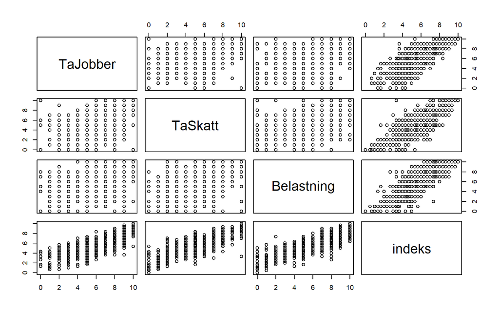

```r
plot(df[,c("TaJobber", "TaSkatt", "Belastning", "indeks")])
```

Hvordan gikk snuoperasjonen?

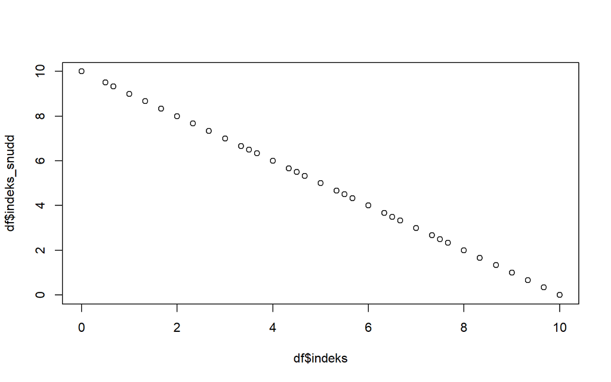

```r
plot(df$indeks, df$indeks_snudd)
```

Hvordan ser fordelingen ut? i.e. fikk jeg egentlig et høyere målenivå?

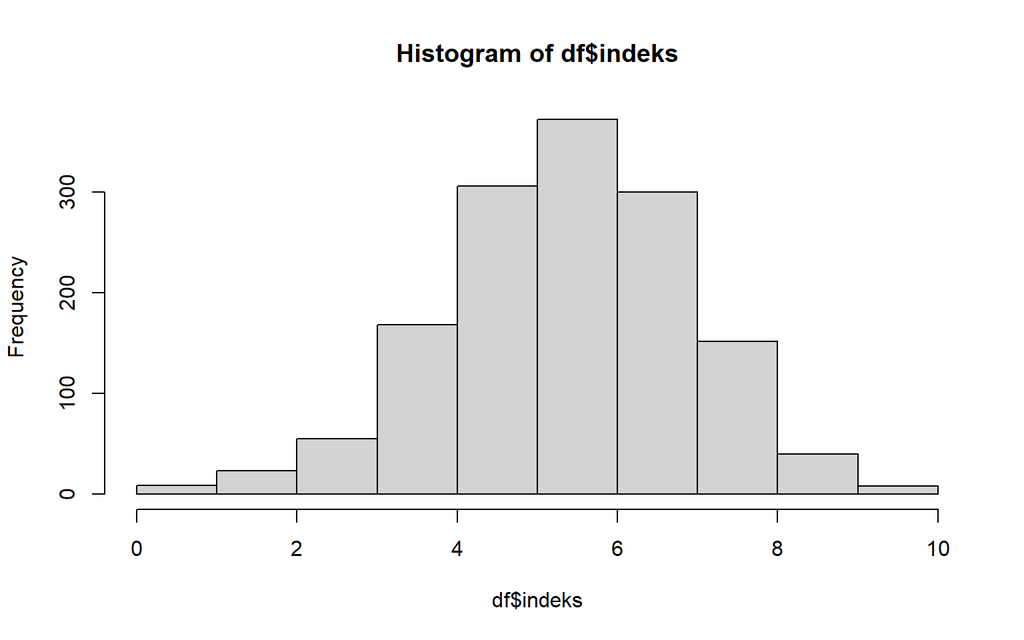

```r
hist(df$indeks)
```

## Betinget omkoding: kategoriske variabler

### For hånd med indeksering

Vi har allerede lekt gjetteleken noen ganger. Den kommer godt med når vi skal omkode.

Her setter jeg én betingelse

```r
df$Inntekt < 3
```

Her setter jeg to

```r
df$Inntekt > 3 & df$Inntekt < 7
```

Lag en ny variabel

```r
df$Inntekt_kat = NA
```

Lav inntekt

```r
df$Inntekt.kat[df$Inntekt <= 3] = "Lav"
```

```r
df$Inntekt.kat[df$Inntekt > 3 & df$Inntekt < 7 ] = "Middels"
```

```r
df$Inntekt.kat[df$Inntekt >= 7 ] = "Hoy"
```

Har det fungert?

```r
table(df$Inntekt.kat)
```

```
##
##     Hoy     Lav Middels
##     495     432     444
```

Hva slags målenivå er dette?

```r
class(df$Inntekt.kat)
```

```
## [1] "character"
```

Skal vi omkode til kategorisk?

```r
df$Inntekt.kat <- factor(df$Inntekt.kat,
                         levels = c("Lav", "Middels", "Hoy"))
```

… eller ordinal

```r
df$Inntekt.kat <- factor(df$Inntekt.kat,
                         levels = c("Lav", "Middels", "Hoy"),
                         ordered = TRUE)
```

## Regelmessige uttrykk (Superkraften!)

Når vi bruker erlik-tegnet, må vi skrive innholdet (verdien) helt korrekt. Men vi kan få R til å kjenne igjen tekstuttryk.

Kjærnefunksjonene i baseR er `gsub()` og `grep()`.

### Ta grep

Her griper jeg bokstavene “dd”. Svaret er linjenummeret i datasettet.

```r
grep("dd", df$Inntekt.kat)
```

Dette kan jeg bruke for omkoding ved hjelp av indeksering. Hvilke inntektsverdier inneholder “dd”?

```r
df$Inntekt.kat[grep("dd", df$Inntekt.kat)]
```

Funksjonen `grepl()` gir TRUE/FALSE-svar. Det er nyttig når du skal lage en ny variabel.

```r
df$rik <- grepl("Hoy", df$Inntekt.kat)
```

R leser TRUE som 1 og FALSE som 0.

```r
sum(df$rik)
```

```
## [1] 495
```

Du kan eksplisitt omkode om du ønsker

```r
df$rik <- grepl("Hoy", df$Inntekt.kat) %>%
  as.numeric()
```

```r
table(df$rik)
```

```
##
##   0   1
## 941 495
```

### Bytt ut

Du kan substituere bokstaver med andre.

```r
gsub(pattern = ". problem",
     replacement = "n utfordring",
     x = "vi har et problem")
```

```
## [1] "vi har en utfordring"
```

Merket du bruken min av “.”?

### Din tur!

Det finnes egne regex-koder for å finne fram regelmessige uttrykk.

Lek deg rundt med kodene fra tabellen!

Mitt forslag:

```r
grep("^noe .*",
     c("ikkenoe", "noe annet", "noe mer", "nei,nei!", "Noe"))
```

```
## [1] 2 3
```

```r
#enda mer inkluderende
grep("^(N|n)oe .*",
     c("ikkenoe", "noe annet", "noe mer", "nei,nei!", "Noe"))
```

```
## [1] 2 3
```

| Regneoperasjon | R |
| --- | --- |
| Hvilken som helst bokstav | [[:alpha:]] |
| Store eller sma bokstaver | [[:upper:]] eller [[:lower:]] |
| Hvilket som helst tall | [[:digit:]] eller \\\\d |
| Ikke tall | \\D |
| Mellomrom | [[:space:]] eller \\\\s |
| Ikke mellomrom | \\\\S |
| Hvilket som helst tegn | . |
| Begynnelsen pa variabelverdien | ^ |
| Slutten pa variabelverdien | $ |

> Dette er grunnsteinen jeg bruker når jeg samler data automatisk (“data scraping”). Men det er også nyttig for å finne alle relevante observasjoner selv om jeg ikke husker/det er skrivefeil i verdinavnene.

## Ferdigfunksjoner

Man kan alltids copy-paste med indeksering og endre teksten vi trenger. Dere kommer dere til mål, men det finnes en del snarveier.

**Hvis/hvis ikke** En praktisk funksjon er hvis/hvis-ikke.

```r
ifelse(df$Inntekt <= 3,
       yes = "Lav",
       no = NA)
```

Denne kan nøstes

```r
ifelse(df$Inntekt <= 3,
       yes = "Lav",
       no = ifelse(df$Inntekt > 7,
                   yes = "Hoy",
                   no = "Middels"))
```

## Piper og `dplyr` ( tidyverse)

dplyr er en fantastisk pakke for tilrettelegging av data; særlig når vi begynner å aggregere.

### Indeksering er ikke nødvendig

I tidyverse, indekserer vi egentlig ikke, men vi kan hente frem spesifikke variabler og observasjoner. Derimot bruker vi ikke disse funksjonene når vi omkoder.

**Spesifikke observasjoner**

```r
#base
df[df$Inntekt > 3,]
```

|  | Parti | Inntekt | Utdanning | Kvinne | Innvandrer | Skepsis | KultSkepsis | TaJobber | TaSkatt | Belastning | Arbeidsledig | Begrenset | IngenKontrakt | Prekaritet | indeks | indeks_snudd | Inntekt_kat | Inntekt.kat | rik |
| --- | --- | --- | --- | --- | --- | --- | --- | --- | --- | --- | --- | --- | --- | --- | --- | --- | --- | --- | --- |
| 1 | FRP | 6 | 9 | 0 | 0 | 3.0000000 | 7.333333 | 6 | 10 | 5 | 0 | 0 | 0 | 0 | 7.0000000 | 3.0000000 | NA | Middels | 0 |
| 6 | A | 8 | 20 | 0 | 1 | 6.3333333 | 3.333333 | 6 | 0 | 5 | 0 | 0 | 0 | 0 | 3.6666667 | 6.3333333 | NA | Hoy | 1 |
| 8 | NA | 4 | 9 | 0 | 1 | 5.3333333 | 5.333333 | 5 | 5 | 4 | 0 | NA | NA | NA | 4.6666667 | 5.3333333 | NA | Middels | 0 |
| 9 | A | 7 | 19 | 0 | 0 | 4.6666667 | 5.333333 | 6 | 5 | 5 | 0 | 0 | 0 | 0 | 5.3333333 | 4.6666667 | NA | Hoy | 1 |
| 12 | FRP | 7 | 14 | 1 | 0 | 7.3333333 | 5.333333 | 2 | 1 | 5 | 0 | 0 | 0 | 0 | 2.6666667 | 7.3333333 | NA | Hoy | 1 |
| 13 | NA | 9 | 8 | 1 | 0 | 5.0000000 | 5.666667 | 7 | 3 | 5 | 0 | 0 | 1 | 1 | 5.0000000 | 5.0000000 | NA | Hoy | 1 |
| 14 | FRP | 9 | 12 | 0 | 0 | 3.3333333 | 3.666667 | 6 | 6 | 8 | 1 | 0 | 0 | 1 | 6.6666667 | 3.3333333 | NA | Hoy | 1 |
| 15 | FRP | 6 | 14 | 1 | 0 | 4.0000000 | 4.666667 | 5 | 6 | 7 | 0 | 0 | 0 | 0 | 6.0000000 | 4.0000000 | NA | Middels | 0 |
| 16 | A | 6 | 7 | 0 | 0 | 4.0000000 | 5.333333 | 5 | 5 | 8 | 0 | 1 | 0 | 1 | 6.0000000 | 4.0000000 | NA | Middels | 0 |
| 17 | H | 4 | 14 | 1 | 0 | 4.6666667 | 5.000000 | 5 | 5 | 6 | 0 | 0 | 0 | 0 | 5.3333333 | 4.6666667 | NA | Middels | 0 |

[output cut: 994 more lines]

```r
#dplyr
df %>%
  filter(Inntekt > 3)
```

|  | Parti | Inntekt | Utdanning | Kvinne | Innvandrer | Skepsis | KultSkepsis | TaJobber | TaSkatt | Belastning | Arbeidsledig | Begrenset | IngenKontrakt | Prekaritet | indeks | indeks_snudd | Inntekt_kat | Inntekt.kat | rik |
| --- | --- | --- | --- | --- | --- | --- | --- | --- | --- | --- | --- | --- | --- | --- | --- | --- | --- | --- | --- |
| 1 | FRP | 6 | 9 | 0 | 0 | 3.0000000 | 7.333333 | 6 | 10 | 5 | 0 | 0 | 0 | 0 | 7.0000000 | 3.0000000 | NA | Middels | 0 |
| 6 | A | 8 | 20 | 0 | 1 | 6.3333333 | 3.333333 | 6 | 0 | 5 | 0 | 0 | 0 | 0 | 3.6666667 | 6.3333333 | NA | Hoy | 1 |
| 8 | NA | 4 | 9 | 0 | 1 | 5.3333333 | 5.333333 | 5 | 5 | 4 | 0 | NA | NA | NA | 4.6666667 | 5.3333333 | NA | Middels | 0 |
| 9 | A | 7 | 19 | 0 | 0 | 4.6666667 | 5.333333 | 6 | 5 | 5 | 0 | 0 | 0 | 0 | 5.3333333 | 4.6666667 | NA | Hoy | 1 |
| 12 | FRP | 7 | 14 | 1 | 0 | 7.3333333 | 5.333333 | 2 | 1 | 5 | 0 | 0 | 0 | 0 | 2.6666667 | 7.3333333 | NA | Hoy | 1 |
| 13 | NA | 9 | 8 | 1 | 0 | 5.0000000 | 5.666667 | 7 | 3 | 5 | 0 | 0 | 1 | 1 | 5.0000000 | 5.0000000 | NA | Hoy | 1 |
| 14 | FRP | 9 | 12 | 0 | 0 | 3.3333333 | 3.666667 | 6 | 6 | 8 | 1 | 0 | 0 | 1 | 6.6666667 | 3.3333333 | NA | Hoy | 1 |
| 15 | FRP | 6 | 14 | 1 | 0 | 4.0000000 | 4.666667 | 5 | 6 | 7 | 0 | 0 | 0 | 0 | 6.0000000 | 4.0000000 | NA | Middels | 0 |
| 16 | A | 6 | 7 | 0 | 0 | 4.0000000 | 5.333333 | 5 | 5 | 8 | 0 | 1 | 0 | 1 | 6.0000000 | 4.0000000 | NA | Middels | 0 |
| 17 | H | 4 | 14 | 1 | 0 | 4.6666667 | 5.000000 | 5 | 5 | 6 | 0 | 0 | 0 | 0 | 5.3333333 | 4.6666667 | NA | Middels | 0 |

[output cut: 929 more lines]

**Spesifikke variabler**: da selekterer du variablene.

```r
#baseR
df[,"Inntekt"]
#dplyr
df %>%
  select(Inntekt)
```

Du vil skjelden bruke `select()` når du koder om. I stedet vil du legge til nye variabler direkte i datasettet. Derimot kan du hente ut variabler når du ser på dataene eller ønsker å dele et “rent” datasett.

### Omkoding: i ett skritt

Når vi lager nye variabler, er `mutate()` gull. Som andre funksjoner i denne serien, kan du legge inn egne funksjoner inn i funksjonen når du oppretter ny variabel. Husk dog å lagre datasettet (her: ved å overskrive).

```r
df <- df %>%
  mutate(Inntekt_omk = ifelse(Inntekt <= 3, "Lav",
                              ifelse(Inntekt > 7, "Hoy", "Middels")))
```

Noter deg hvordan jeg ikke indekserer. Jeg jobber hele tiden med hele datasettet, men presiserer hvilke variabler og variabelverdier som skal brukes for å opprette den nye variabelen.

Sjekk:

```r
df$Inntekt_omk %>% table
```

```
## .
##     Hoy     Lav Middels
##     378     432     561
```

# Slå sammen data

Ofte vil vi slå sammen informasjon (aggregere) eller datasett.

Vi begynner med å laste inn datasettet fra Chapel Hill-undersøkelsen.

Jeg begynner med å laste ned dataene fra nettet og inn i R.

```r
#Fra lokal fil
load("kap6b.rda")
#eller rett ned fra nettet
load(url("https://siljehermansen.github.io/teaching/oslomet/kap6b.rda"))
#endre navn
df2 <- kap6b
```

Sjekk ut

```r
head(df2)
```

|  | id | party_name | immigrate_policy |
| --- | --- | --- | --- |
| 1 | 1 | A | NA |
| 2 | 2 | A | 6 |
| 3 | 3 | A | 6 |
| 4 | 4 | A | 4 |
| 5 | 1 | FrP | 9 |
| 6 | 2 | FrP | 9 |

Datastrukturen består av flere eksperter som uttaler seg om samme parti; et klassisk eksempl på noe jeg ønsker å aggregere til parti-nivå.

## Aggregere data

`group_by()` revolusjonerte mitt liv. Her tar jeg gjennomsnitlig holdning til innvandring for hvert parti. Da får jeg rangert partiene etter holdning.

```r
df2 <- df2 %>%
  group_by(party_name) %>%
  mutate(skepsis = mean(immigrate_policy))
```

Det er viktig å gi funksjonene til R i riktig rekkefølge: Du ønsker å gruppere dataene først, så omkode; ikke omvent!

Hvordan ser norske partiers holdninger ut?

```r
df2 %>%
  #Velg de to variablene jeg er interessert i
  select(party_name, skepsis) %>%
  #Fjern alle duplikater
  unique()
```

| party_name | skepsis |
| --- | --- |
| A | NA |
| FrP | NA |
| H | NA |
| SV | NA |
| Sp | NA |
| KrF | NA |
| V | NA |
| MDG | NA |

… ooops… jeg hadde hull i datasettet. Rykk to skritt bakover og legg til `na.rm = T` (den gode, gamle R-problematikken).

```r
df2 <- df2 %>%
  group_by(party_name) %>%
  mutate(skepsis = mean(immigrate_policy, na.rm = T))
#Gikk det nå?
df2 %>%
  #Velg de to variablene jeg er interessert i
  select(party_name, skepsis) %>%
  #Fjern alle duplikater
  unique()
```

| party_name | skepsis |
| --- | --- |
| A | 5.333333 |
| FrP | 9.000000 |
| H | 6.333333 |
| SV | 2.000000 |
| Sp | 5.666667 |
| KrF | 3.000000 |
| V | 2.333333 |
| MDG | 2.000000 |

Jeg kan organisere dataene

```r
df2 %>%
  #Velg de to variablene jeg er interessert i
  select(party_name, skepsis) %>%
  #Fjern alle duplikater
  unique() %>%
  #sorter fra lav til høy
  arrange(skepsis)
```

| party_name | skepsis |
| --- | --- |
| SV | 2.000000 |
| MDG | 2.000000 |
| V | 2.333333 |
| KrF | 3.000000 |
| A | 5.333333 |
| Sp | 5.666667 |
| H | 6.333333 |
| FrP | 9.000000 |

Her skal jeg legge informasjon om innnvandringskepsis på partinivå til ESS dataene på respondentnivå.

Aller først må jeg sjekke om partinavnene er de samme.

```r
df$Parti %>% unique
```

```
##  [1] FRP   A     KRF   H     <NA>  MDG   SV    SP    Other V     RODT  KYST
## Levels: A FRP H KRF KYST MDG Other RODT SP SV V
```

```r
df2$party_name %>% unique
```

```
## [1] A   FrP H   SV  Sp  KrF V   MDG
## Levels: A FrP H KrF MDG SV Sp V
```

Jeg bør bruke øynene, men jeg kan også sjekke på andre måter. Her spør jeg om alle partiene fra ESS (df) er tilstede i CHES (df2).

```r
all(df$Parti %in% df2$party_name)
```

```
## [1] FALSE
```

Det er de visst ikke.

Hvilke observasjoner *har* jeg data på?

```r
df$Parti[df$Parti %in% df2$party_name] %>% unique
```

```
## [1] A   H   MDG SV  V
## Levels: A FRP H KRF KYST MDG Other RODT SP SV V
```

Hvilke observasjoner har jeg *ikke* data på?

```r
df$Parti[!df$Parti %in% df2$party_name] %>% unique
```

```
## [1] FRP   KRF   <NA>  SP    Other RODT  KYST
## Levels: A FRP H KRF KYST MDG Other RODT SP SV V
```

### Din tur!

Her må vi kode om: noen av partiene inneholder små bokstaver. Kod om CHES dataene (df2) slik at alle partier korresponderer med ESS (df).

- kan du komme på en løsning selv?
- forsøk denne løsningen: omkod begge variabler til små bokstaver ved hjelp av `tolower()` eller `toupper()`.
- bruk `%in%` for å sjekke om du fikk det riktig.

## Legge til variabler: nøkler

Personlig legger jeg ofte variablene til hoveddatasettet mitt én etter én. Da har jeg kontroll.

Jeg begynner med `match()`. Funksjonen kommer fra baseR og rapporterer observasjonsnummeret til variabel2 i rekkefølgen til variabel1.

```r
match(tolower(df$Parti),
            tolower(df2$party_name))[1:10]
```

```
##  [1]  5  1 21  9  5  1  9 NA  1  9
```

Her er første parti i ESS dataene (df) det femte partiet i CHES (df2). Det kan jeg bruke til å indeksere. For enkeltheltsskyld tar jeg vare på indeksen i et objekt og bruker den.

```r
id <- match(tolower(df$Parti),
            tolower(df2$party_name))
```

Jeg ønsker å overføre innvandringsskepsis fra CHESS til ESS. Indeksvariabelen min `id` sørger for at `df2$skepsis[id]` er like lang som df. Dermed kan jeg ganske enkelt kopiere variabelen over.

```r
df2$skepsis[id]
df$Skepsis_parti  <- df2$skepsis[id]
```

Ha tunga rett i munn når du gjør dette; det blir snart en (u)vane. R gir deg beskjed om de to vektorene er av ulik lengde. Da har du indeksert feil.

### Din tur

Nå kan vi sjekke om respondentene og partiene de stemte på har omtrent samme holdning til innvandring! Hvilke partier har størst avstand fra velgerne sine?

- korreler de to ved hjelp av `cor.test()`

```r
cor.test(df$Skepsis, df$Skepsis_parti)
```

```
##
##  Pearson's product-moment correlation
##
## data:  df$Skepsis and df$Skepsis_parti
## t = 10.848, df = 1052, p-value < 2.2e-16
## alternative hypothesis: true correlation is not equal to 0
## 95 percent confidence interval:
##  0.2618089 0.3704663
## sample estimates:
##       cor
## 0.3171781
```

- aggreger/regn ut den gjennomsnitlige differansen mellom velgerne og partiet ved hjelp av `group_by()` i dplyr. Da kan det være nyttig å ta den absolutte differensen ved hjelp av `abs()`; f.eks `abs(1-2)`

```r
df %>%
  group_by(Parti) %>%
  summarize(distanse = mean(abs(Skepsis - Skepsis_parti),
                            na.rm = T)) %>%
  #Sorterer i nedadgående (descending) verdier
  arrange(desc(distanse))
```

| Parti | distanse |
| --- | --- |
| FRP | 3.481481 |
| H | 1.948171 |
| MDG | 1.728395 |
| SV | 1.646259 |
| KRF | 1.596154 |
| V | 1.520513 |
| SP | 1.514124 |
| A | 1.494592 |
| KYST | NaN |
| Other | NaN |

[output cut: 2 more lines]

## Slå sammen hele datasett